# Onboarding Tutorial

Jen Wang

6/1/2021

# PART I: Web Scrapping Tutorial

## Rselenium Package & rvest Package Install these two packages and comment out the codes. #install.packages("Rselenium") #install.packages("rvest") library(RSelenium) library(rvest) **Static Web Pages** are web pages that display the fixed contents and deliver the same pages to all users; **Dynamic Web Pages** are pages that can display different contents and information change occurs frequently, some also provide user interaction. If you tried scraping a Dynamic web page, you might not obtain dynamic information by `rvest::read_html()`. As such, two option can be used to overcome this issue: Save the web page in complete format Using `Rselenium` Package to obtain dynamic webpages. Using Google Chrome Browser to open the web page. Download the page as “webpage, complete” format. Using `rvest::read_html()` to read the webpage in r. `Rselenium` Package is a tool to navigate websites and it can be combined with the `rvest` package to scrape dynamic web pages. **Prerequisites** Check which version your browser is running on. Depending on your browser type, I am using Chrome here. Click the top right three dots -> Help -> About Google Chrome to see which version you are on. For mine, it indicates that Chrome is running on Version 91.0.4472.77(Version 91) Next [download](https://chromedriver.chromium.org/downloads) the current Selenium web drivers for your Chrome version. Then select the chromedriver corresponding your computer system.(I am using mac here) Download the latest stable version of [Selenium Server](https://www.selenium.dev/downloads/) and save it to the appropriate folder. Open the terminal and change the directory to where you save the Selenium Server .jar and then enter `java -Dwebdriver.chrome.driver=chromedriver -jar selenium-server-standalone-3.141.59.jar`. Here `-jar selenium-server-standalone-3.141.59.jar` is the name of the file you just downloaded. Once you see that *“Selenium Server is up and running on port 4444”*, then Selenium Server has been successfully installed and ready to use. remDr <- remoteDriver(remoteServerAddr = "localhost", port = 4444, browserName ="chrome") remDr$open() If everything above worked correctly, a new chrome window will open. This window should look like this: Then you are able to read the dynamic website using following code: remDr$navigate("https://www.columbia.edu/") page <- rvest::read_html(remDr$getPageSource()[[1]])

[figure not shown]

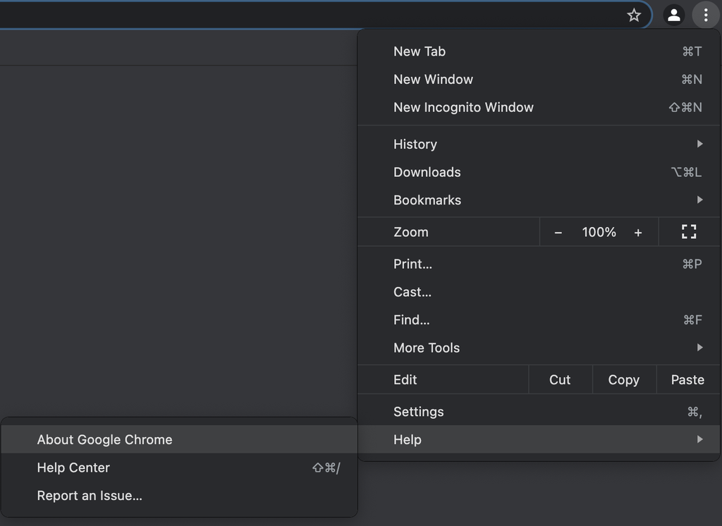

[figure not shown]

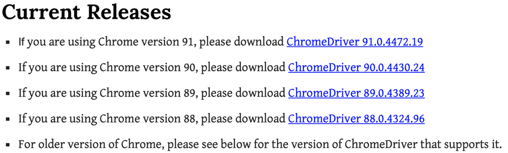

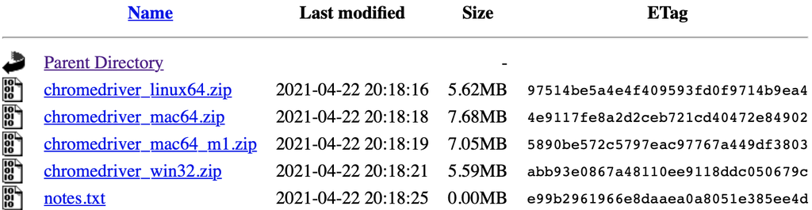

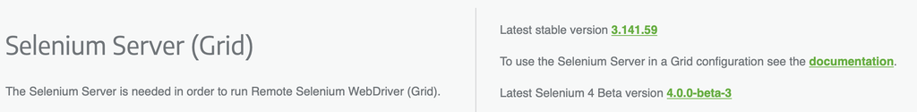

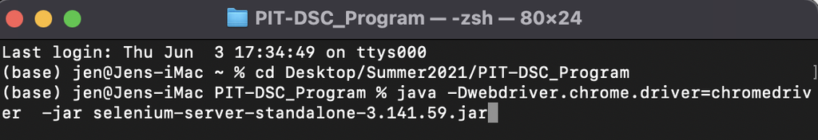

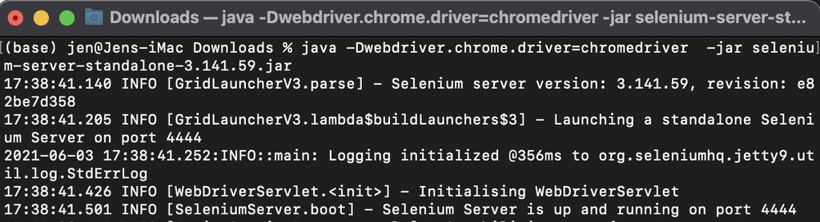

[figure not shown]

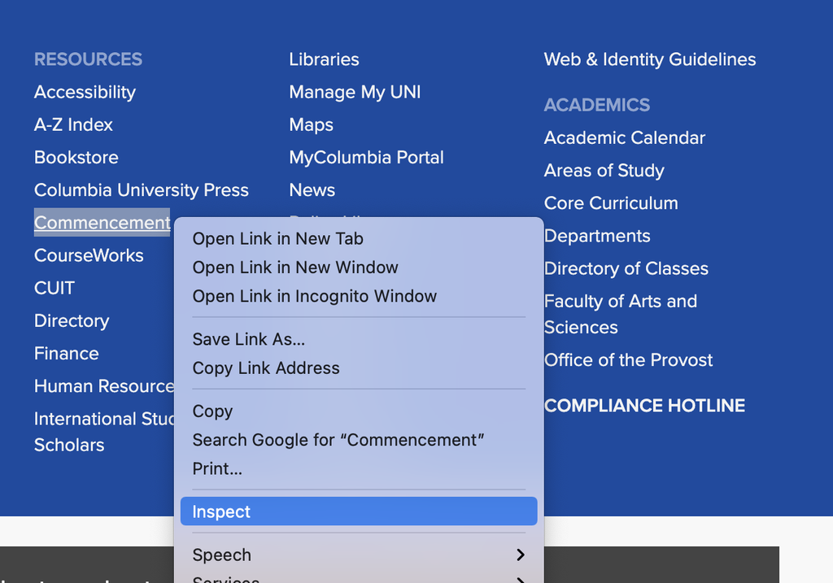

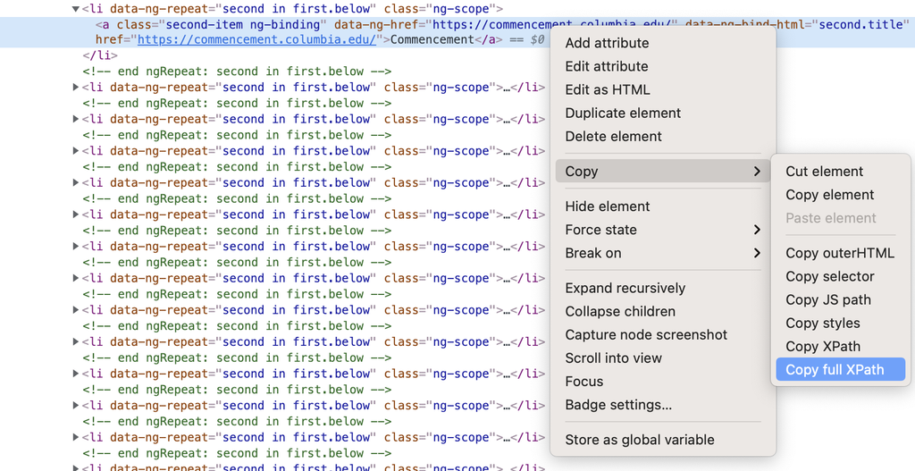

# PART II: PDF Parsing Tutorial

[Note"] There are many resources for parsing pdf documents. I will introduce `pdftools` package and `tabulizer` package in this tutorial.

### Install and load the packages #install.packages("pdftools") #install.packages("tabulizer") library(pdftools) ## Using poppler version 20.12.1 library(tabulizer)

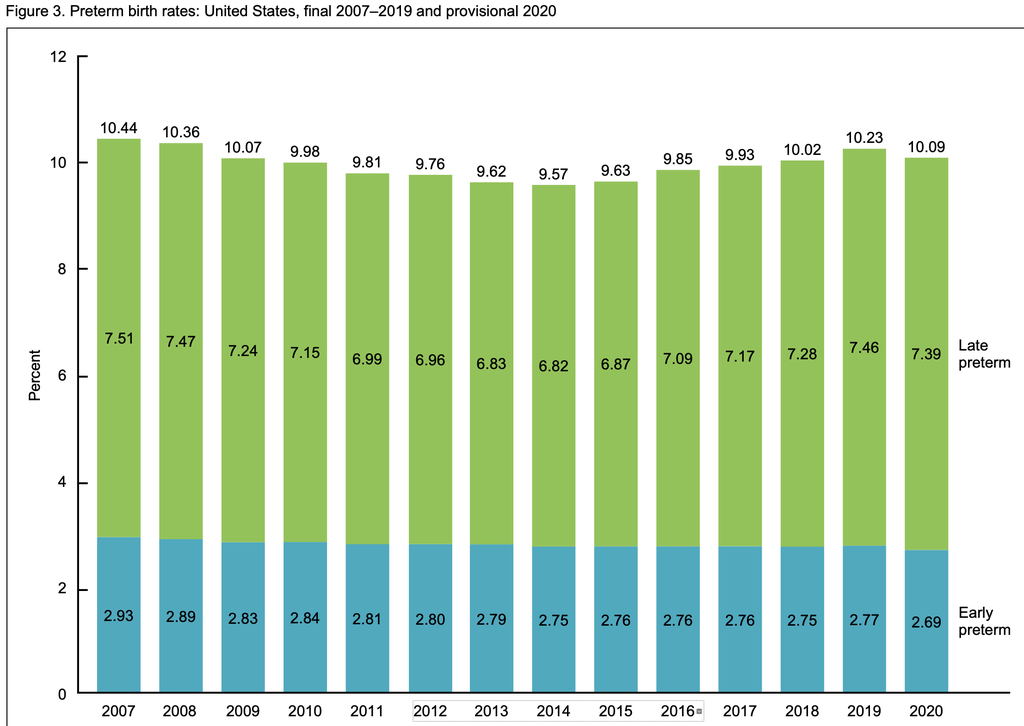